# Tejash - Unsupervised Learning - Credit Card Customer Segmentation

### Hierarchical Clustering

```python
#importing libraries
from scipy.cluster.hierarchy import cophenet, dendrogram, linkage
```

```python
Z = linkage(subset_scaled_df, metric='euclidean', method='ward')
c, coph_dists = cophenet(Z , pdist(subset_scaled_df))

c
```

```
0.7415156284827493
```

Cophenetic Score of closer to 1 means better clustering. We are able to achieve a score of 0.74 which is not as good. We can try other methods

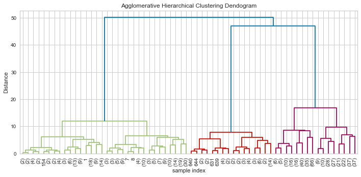

```python
# Plotting dendogram
plt.figure(figsize=(10, 5))
plt.title('Agglomerative Hierarchical Clustering Dendogram')
plt.xlabel('sample index')
plt.ylabel('Distance')
dendrogram(Z,leaf_rotation=90.0,p=5,color_threshold=45,leaf_font_size=10,truncate_mode='level')
plt.tight_layout()
```

```python
Z = linkage(subset_scaled_df, metric='euclidean', method='average')
c, coph_dists = cophenet(Z , pdist(subset_scaled_df))

c
```

```
0.8977080867389372
```

Cophenetic score of 0.89 is better than wards methods.

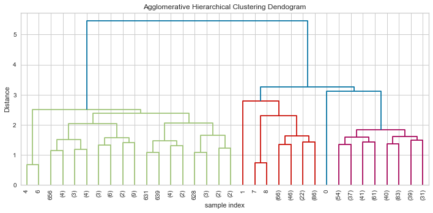

```python
# Plotting dendogram
plt.figure(figsize=(10, 5))
plt.title('Agglomerative Hierarchical Clustering Dendogram')
plt.xlabel('sample index')
plt.ylabel('Distance')
dendrogram(Z,leaf_rotation=90.0,p=5,color_threshold=3,leaf_font_size=10,truncate_mode='level')
plt.tight_layout()
```

```python
Z = linkage(subset_scaled_df, metric='euclidean', method='complete')
c, coph_dists = cophenet(Z , pdist(subset_scaled_df))

c
```

```
0.8599730607972423
```

Complete method provides a score of 0.85, average still gives better score.

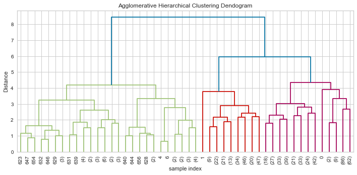

```python
#plotting dendogram
plt.figure(figsize=(10, 5))
plt.title('Agglomerative Hierarchical Clustering Dendogram')
plt.xlabel('sample index')
plt.ylabel('Distance')
dendrogram(Z,leaf_rotation=90.0,p=5,color_threshold=5,leaf_font_size=10,truncate_mode='level')
plt.tight_layout()
```

```python
Z = linkage(subset_scaled_df, metric='euclidean', method='single')
c, coph_dists = cophenet(Z , pdist(subset_scaled_df))

c
```

```
0.7391220243806552
```

0.73 is not the best score yet.

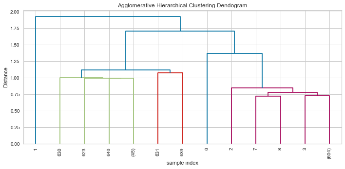

```python
#plotting dendogram
plt.figure(figsize=(10, 5))
plt.title('Agglomerative Hierarchical Clustering Dendogram')
plt.xlabel('sample index')
plt.ylabel('Distance')
dendrogram(Z,leaf_rotation=90.0,p=5,color_threshold=1.10,leaf_font_size=10,truncate_mode='level')
plt.tight_layout()
```

```python
Z = linkage(subset_scaled_df, metric='euclidean', method='centroid')
c, coph_dists = cophenet(Z , pdist(subset_scaled_df))

c
```

```
0.8939385846326323
```

Cophentic score for Centroid method is same as for Average method.

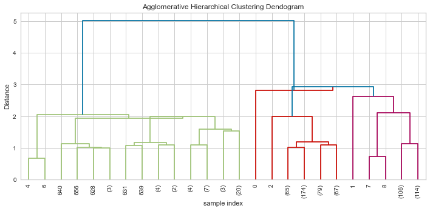

```python
#plotting dendogram
plt.figure(figsize=(10, 5))
plt.title('Agglomerative Hierarchical Clustering Dendogram')
plt.xlabel('sample index')
plt.ylabel('Distance')
dendrogram(Z,leaf_rotation=90.0,p=5,color_threshold=2.9,leaf_font_size=10,truncate_mode='level')
plt.tight_layout()
```

```python
#importing library
from sklearn.cluster import AgglomerativeClustering
```

```python
#creating model with Average linkage
model = AgglomerativeClustering(n_clusters=3, affinity='euclidean',  linkage='average')
model.fit(subset_scaled_df)
```

```
AgglomerativeClustering(linkage='average', n_clusters=3)
```

```python
#creating a duplicate dataframe and appending labels.
hcdf = df.copy()
hcdf['labels'] = model.labels_
hcdf.head(10)
```

|  | Customer Key | Avg_Credit_Limit | Total_Credit_Cards | Total_visits_bank | Total_visits_online | Total_calls_made | labels |
| --- | --- | --- | --- | --- | --- | --- | --- |
| 0 | 87073 | 100000 | 2 | 1 | 1 | 0 | 0 |
| 1 | 38414 | 50000 | 3 | 0 | 10 | 9 | 2 |
| 2 | 17341 | 50000 | 7 | 1 | 3 | 4 | 0 |
| 3 | 40496 | 30000 | 5 | 1 | 1 | 4 | 0 |
| 4 | 47437 | 100000 | 6 | 0 | 12 | 3 | 1 |
| 5 | 58634 | 20000 | 3 | 0 | 1 | 8 | 2 |
| 6 | 48370 | 100000 | 5 | 0 | 11 | 2 | 1 |
| 7 | 37376 | 15000 | 3 | 0 | 1 | 1 | 2 |
| 8 | 82490 | 5000 | 2 | 0 | 2 | 2 | 2 |
| 9 | 44770 | 3000 | 4 | 0 | 1 | 7 | 2 |

```python
#grouping by over labels
cluster_profileHC = hcdf.groupby('labels').mean()
```

```python
cluster_profileHC['count_in_each_segment'] = hcdf.groupby('labels')['Avg_Credit_Limit'].count().values
```

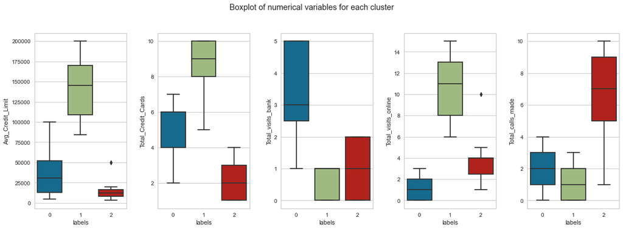

```python
#plotting box plots
fig, axes = plt.subplots(1, 5,  figsize=(16, 6))
fig.suptitle('Boxplot of numerical variables for each cluster')
counter = 0
for ii in range(5):
    sns.boxplot(ax=axes[ii],y=hcdf[all_col[counter]],x=hcdf['labels'])
    counter = counter+1

fig.tight_layout(pad=2.0)
```